# TKET: Quantinuum’s advanced quantum SDK for the NISQ era

Kathrin Spendier → kathrin.spendier@quantinuum.com,

Notebook and slides available at: → https://github.com/spendierk/Q-SITE-Toronto-2022

[figure not shown]

## Quantinuum's Model is Built Around Platform Inclusivity

[figure not shown]

## Workshop Contents

This tutorial will explore tools available in TKET, providing a comprehensive, feature-focused tour of the platform.

We will cover:

1. Installing and getting started with TKET and it's extensions.
2. Quantum gates, measurement and the construction of quantum circuits.
3. Tools that enable moving code between devices and software packages.
4. Steps required to prepare circuits to be run on a quantum computer.
5. Running circuits on quantum computers and classical simulators.

# The State of Quantum Computers and SDK

Noise:

- Noisy Intermediate-Scale Quantum → low numbers of qubits and high error rates.
- Error correction, break encryption, Grover's search → ❌

Operations:

- The devices will often only support a small fragment of quantum circuits.
- Only possible to perform multi-qubit operations between specific pairs of qubits.

Software:

- Utilisation of desirable devices may be locked behind specific interface software.

## What is TKET?

TKET is a software platform for the development and execution of gate-level quantum computation.

It automatically handles many of the intricacies of NISQ technology.

In Particular TKET:

- Noise and operations → Provides state-of-the-art performance in circuit compilation and optimisation.
- Software → Facilitates platform-agnostic software development, allowing code reuse.

Frees the user to focus on the technique or project they are working on!

## Getting Started

There is currently an implementation of TKET available in the form of the pytket python package.

`pip install pytket`

Additional extension modules are available for interfacing pytket with several quantum software packages, including: Qiskit, Cirq, pyQuil, and others.

`pip install pytket-qiskit`

Documentation and examples are available → https://cqcl.github.io/tket/pytket/api/, and TKET is also open source → https://github.com/CQCL/tket.

# How Are Quantum Circuits Constructed?

- Basic and advanced gates
- Measurement

## Basic Gates

Let's start by building a familiar circuit to generate the bell pair: $$ \left| \psi \right\rangle = \frac{1}{\sqrt{2}} \left( \left| 00 \right\rangle + \left| 11 \right\rangle\right) $$ The simplest way to build a circuit in pytket is by adding gates sequentially.

In bra-ket notation: $$ \mathsf{CX} ( \mathsf{H} \otimes \mathsf{I} ) \left| 00 \right\rangle = \mathsf{CX} \frac{1}{\sqrt{2}}\left( \left| 0 \right\rangle + \left| 1 \right\rangle \right) \left| 0 \right\rangle = \frac{1}{\sqrt{2}} \left( \left| 00 \right\rangle + \left| 11 \right\rangle\right)$$ where: $$ \mathsf{CX} = \begin{bmatrix} 1 & 0 & 0 & 0\\ 0 & 1 & 0 & 0\\ 0 & 0 & 0 & 1\\ 0 & 0 & 1 & 0 \end{bmatrix} \quad \text{and} \quad \mathsf{H} = \frac{1}{\sqrt{2}} \begin{bmatrix} 1 & 1 \\ 1 & -1 \end{bmatrix} $$

The `Circuit` class is the unit of computation sent to a quantum processor.

```python
from pytket import Circuit
from pytket.circuit.display import render_circuit_jupyter

circ = Circuit(2)
circ.H(0).CX(0,1)

render_circuit_jupyter(circ)
```

[interactive chart not shown]

Gates are added in order of execution. The circuit is typically assumed to act on the state $\left| 0^n \right\rangle$, producing a new state at the end.

```python
from pytket.extensions.qiskit import AerStateBackend
import numpy as np

backend = AerStateBackend()
result = backend.run_circuit(circ)
result_state = result.get_state()

print(f"State verctor -> {np.round(result_state, 3)}")
```

```
State verctor -> [0.707+0.j 0.   +0.j 0.   +0.j 0.707+0.j]
```

$$ \left| \psi \right\rangle = \frac{1}{\sqrt{2}} \left( \left| 00 \right\rangle + \left| 11 \right\rangle\right) $$

TKET also includes a plethora of other gates, including:

- Paramterised gates → angle given first, and in units of $ \pi $.
- Control gates → control qubits given first, then target.

Less common gates available through `OpType` enum.

```python
from pytket import OpType

circ = Circuit(3)

circ.Rx(0.5, 0)
circ.CRz(0.3, 1, 2)
circ.add_gate(OpType.CnX, [0, 2, 1])

render_circuit_jupyter(circ)
```

[interactive chart not shown]

## Device Specific Gates

You'll find gates for a selection of devices in pytket. These include devices from Rigetti, IBM, OQC, Google, etc.

In the case of the Quantinuum devices, an instance of the $ \mathsf{ZZPhase} $ is native. $$ \mathsf{ZZPhase} : \left( \alpha \right) \rightarrow e^{-\frac{1}{2} i \pi \alpha \mathsf{Z} \otimes \mathsf{Z}} = \begin{bmatrix} e^{-\frac{1}{2} i \pi \alpha} & 0 & 0 & 0\\ 0 & e^{\frac{1}{2} i \pi \alpha} & 0 & 0\\ 0 & 0 & e^{\frac{1}{2} i \pi \alpha} & 0\\ 0 & 0 & 0 & e^{-\frac{1}{2} i \pi \alpha} \end{bmatrix} $$ In particular $ \mathsf{ZZPhase}\left( \frac{1}{2} \right) $ is used, and can be accessed as the $ \mathsf{ZZMax} $ gate via pytket.

```python
circ = Circuit(4)

circ.add_gate(OpType.ZZPhase, 0.7, [0, 2])
circ.add_gate(OpType.ZZMax, [1, 3])
circ.add_gate(OpType.PhasedX, [-0.1, 0.5], [3])

render_circuit_jupyter(circ)
```

[interactive chart not shown]

## Universal gate sets

Native gates for devices are typically as subset of all quantum gates. However this set is *universal*.

- A set of universal quantum gates is any set of gates to which any operation possible on a quantum computer can be reduced.
- The Solovay–Kitaev theorem guarantees that any quantum operation can be efficiently approximated by a sequence of gates from this finite set.

$\textsf{TK1}$ and $\textsf{CNOT}$ are together universal. Any single qubit gate can be implemented using the $ \textsf{TK1} $ gate.

$$ \textsf{TK1} : \left( \alpha , \beta , \gamma \right) \rightarrow \textsf{RZ} \left( \alpha \right) \textsf{RX} \left( \beta \right) \textsf{RZ} \left( \gamma \right) $$

```python
angles = [0.1, 0.2, 0.3]

circ_tk = Circuit(1)
circ_tk.add_gate(OpType.TK1, angles, [0])
render_circuit_jupyter(circ_tk)

circ_r = Circuit(1)
circ_r.Rz(angles[2], 0).Rx(angles[1], 0).Rz(angles[0], 0)
render_circuit_jupyter(circ_r)
```

[interactive chart not shown]

## Arbitrary Two Qubit Gates

As well as arbitrary single qubit gates, implemented via the $ \textsf{TK1} $ gate, pytket allows for arbitrary two qubit, and indeed three qubit, gates to be defined using unitary matrices.

```python
from pytket.circuit import Unitary2qBox
from scipy.stats import unitary_group

x = unitary_group.rvs(4)
two_q_box = Unitary2qBox(x)
print(np.around(two_q_box.get_matrix(), 2))
```

```
[[ 0.56-0.03j  0.62+0.16j -0.  +0.06j  0.41+0.31j]
 [-0.56-0.26j  0.28+0.j    0.35-0.38j -0.02+0.53j]
 [ 0.31+0.13j -0.02-0.68j -0.12-0.j   -0.45+0.46j]
 [-0.11+0.42j  0.  -0.22j  0.68+0.51j  0.2 +0.01j]]
```

```python
circ = Circuit(3).H(0).H(1).H(2)
circ.add_unitary2qbox(two_q_box, qubit_0=0, qubit_1=2)

render_circuit_jupyter(circ)
```

[interactive chart not shown]

## Measurement

Measurements produce classical data from the resulting state.

- All measurements are single-qubit measurements in the $ \mathsf{Z} $ basis.
- Other forms of measurements can be constructed by combining these with other operations.

[interactive chart not shown]

```
State verctor -> [0.707+0.j 0.   +0.j 0.   +0.j 0.707+0.j]
```

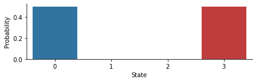

```python
circ = Circuit(2).H(0).CX(0,1)

backend = AerStateBackend()
result_state = backend.run_circuit(circ).get_state()

render_circuit_jupyter(circ)
print(f"State verctor -> {np.round(result_state, 3)}")
plot_state_probs(result_state)
```

```python
circ = Circuit(2,2).H(0).CX(0,1).measure_all()
render_circuit_jupyter(circ)
```

[interactive chart not shown]

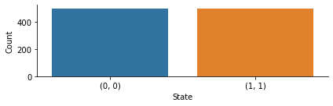

```python
from pytket.extensions.qiskit import AerBackend

backend = AerBackend()
result_counts = backend.run_circuit(circ, n_shots=1000).get_counts()
plot_counts(result_counts)
```

# Importing, Exporting and Analysing Quantum Circuits

TKET allows users to:

- Seamlessly move between software packages.
- Export circuits to commonly accepted standard representations.
- Analyse circuits to gauge their complexity.

Converters for other quantum software frameworks can optionally be included by installing the corresponding extension module. These are additional PyPI packages with names pytket-X.

`pip install pytket-qiskit`

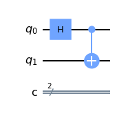

```python
from qiskit import QuantumCircuit

qiskit_circ = QuantumCircuit(2, 2)

qiskit_circ.h(0)
qiskit_circ.cx(0, 1)

qiskit_circ.draw(output='mpl')
```

```python
from pytket.extensions.qiskit import qiskit_to_tk

tket_circ = qiskit_to_tk(qiskit_circ)
tket_circ.H(0)
tket_circ.measure_all()

render_circuit_jupyter(tket_circ)
```

[interactive chart not shown]

```python
from pytket.extensions.qiskit import tk_to_qiskit
from qiskit import Aer
from qiskit import assemble

sv_sim = Aer.get_backend('aer_simulator')

tket_circ = Circuit(3).X(0).H(2).CX(0,1)
qiskit_circ = tk_to_qiskit(tket_circ)
qiskit_circ.measure_all()

qobj = assemble(qiskit_circ, shots=1000)
job = sv_sim.run(qobj)
hist = job.result().get_counts()
print(hist)
```

```
{'111': 468, '011': 532}
```

One of TKET's newest extensions allows users to use PennyLanes's QML tools to solve their problems and then use TKET for compilation, optimization, and backend execution.

This allows users to take advantage of each platform's strengths.

`pip install pytket-pennylane`

### Chemistry-Inspired Circuit for $H_2$

Sample circuit to compute the ground state energies for the hydrogen atom was obtained by InQuanto using the simplest qubit mapper/converter called the Jordan-Wigner Mapper.

OpenQASM is one of the current industry standards for low-level circuit description languages and is widely supported. It servers as a platform-independent method of storing circuits. TKET has bidirectional conversion support for QASM.

```python
from pytket.qasm import circuit_from_qasm, circuit_to_qasm, circuit_to_qasm_str

circ = circuit_from_qasm('H2JordanWignerMapper.qasm')
render_circuit_jupyter(circ)
```

[interactive chart not shown]

```python
print(circuit_to_qasm_str(circ))
```

```
OPENQASM 2.0;
include "qelib1.inc";

qreg q[4];
x q[0];
sx q[1];
x q[2];
sx q[3];
h q[0];
h q[2];
cx q[1],q[0];
cx q[3],q[2];
rz(0.5*pi) q[0];
rz(0.5*pi) q[2];
cx q[1],q[0];
cx q[3],q[2];
h q[0];
sxdg q[1];
h q[2];
sxdg q[3];
sx q[0];
h q[1];
sx q[2];
h q[3];
cx q[1],q[0];
cx q[3],q[2];
rz(3.5*pi) q[0];
rz(3.5*pi) q[2];
cx q[1],q[0];
cx q[3],q[2];
sxdg q[0];
h q[1];
sxdg q[2];
h q[3];
sx q[0];
sx q[1];
h q[2];
sx q[3];
cx q[3],q[2];
cx q[2],q[1];
```

[output cut: 99 more lines]

```
sxdg q[2];
h q[3];
sx q[2];
h q[3];
cx q[3],q[2];
cx q[2],q[1];
cx q[1],q[0];
rz(3.8750001487587995*pi) q[0];
cx q[1],q[0];
h q[0];
cx q[2],q[1];
h q[1];
cx q[3],q[2];
sxdg q[2];
h q[3];
```

## Circuit Analysis

Common circuit metrics like gate count and depth are used to approximate the difficulty of running it on a device, providing some basic tools to help distinguish different implementations of a given algorithm.

- On NISQ technology two-qubit gates are much slower and noisier.
- Looking forward to the fault-tolerant regime, we will expect Clifford gates to be very cheap, but the T gate to require an expensive distillation procedure.

Let's anayze our chemistry-inspired circuit for $H_2$

```python
print(f"Number of gates = {circ.n_gates}")
print(f"Circuit depth = {circ.depth()}")
print(f"Number of CX gates = {circ.n_gates_of_type(OpType.CX)}")
```

```
Number of gates = 150
Circuit depth = 83
Number of CX gates = 56
```

# Preparing and Running Quantum Circuits

In practice running on a real device is a little more complicated.

- So far we have used ideal classical simulators, which are noise free, do not have architectures, and have a diverse gate set.
- Now we want to run our chemistry inspired circuit on the IBMQ Guadalupe Emulator and Quantinuum H1-1 Emulator.

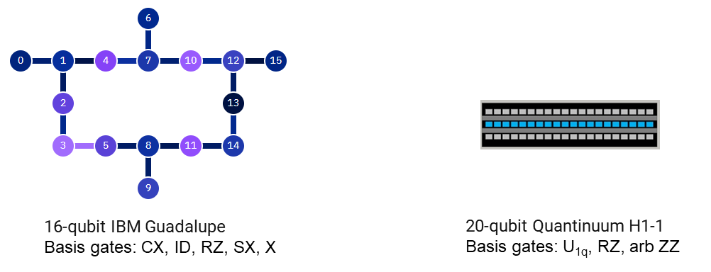

```python
from pytket.extensions.qiskit import IBMQEmulatorBackend
from qiskit import IBMQ

dev_b = IBMQEmulatorBackend('ibmq_guadalupe',
                                  hub='partner-cqc', group='internal', project='default')
print(dev_b.backend_info.gate_set)
```

```
{<OpType.Rz: 33>, <OpType.U3: 34>, <OpType.U2: 35>, <OpType.U1: 36>, <OpType.CX: 39>, <OpType.Reset: 60>, <OpType.X: 20>, <OpType.noop: 57>, <OpType.Measure: 58>, <OpType.SX: 28>}
```

```python
render_circuit_jupyter(circ)
```

[interactive chart not shown]

```python
from pytket.utils import Graph
Graph(circ).get_qubit_graph()
```

[figure not shown]

TKET has a default pass manager for each backend:

`get_compiled_circuit(circuit,optimisation_level)`

```python
compiled_qft_circ = dev_b.get_compiled_circuit(circ,0)
render_circuit_jupyter(compiled_qft_circ)
```

[interactive chart not shown]

```python
print("Gate set:", dev_b.backend_info.gate_set)
```

```
Gate set: {<OpType.Rz: 33>, <OpType.U3: 34>, <OpType.U2: 35>, <OpType.U1: 36>, <OpType.CX: 39>, <OpType.Reset: 60>, <OpType.X: 20>, <OpType.noop: 57>, <OpType.Measure: 58>, <OpType.SX: 28>}
```

```python
# our initial circuit

print(f"Number of gates = {circ.n_gates}")
print(f"Circuit depth = {circ.depth()}")
print(f"Number of CX gates = {circ.n_gates_of_type(OpType.CX)}")
```

```
Number of gates = 150
Circuit depth = 83
Number of CX gates = 56
```

```python
# compile to IBM Belem by solving the device constraints without optimizing (level 0)

compiled_qft_circ = dev_b.get_compiled_circuit(circ,0)

print(f"Number of gates = {compiled_qft_circ.n_gates}")
print(f"Circuit depth = {compiled_qft_circ.depth()}")
print(f"Number of CX gates = {compiled_qft_circ.n_gates_of_type(OpType.CX)}")
```

```
Number of gates = 247
Circuit depth = 114
Number of CX gates = 59
```

```python
# compile to IBM Belem by solving the device constraints with optimization Lelvel 2

compiled_qft_circ2 = dev_b.get_compiled_circuit(circ,2)

print(f"Number of gates = {compiled_qft_circ2.n_gates}")
print(f"Circuit depth = {compiled_qft_circ2.depth()}")
print(f"Number of CX gates = {compiled_qft_circ2.n_gates_of_type(OpType.CX)}")
```

```
Number of gates = 74
Circuit depth = 48
Number of CX gates = 17
```

Let's compile the circuit using Qiskit's default Qasm Simulator for the noisy Guadalupe backend:

```python
cq = tk_to_qiskit(circ)

from qiskit import IBMQ, transpile, QuantumCircuit
from qiskit import QuantumCircuit, QuantumRegister, IBMQ, execute

# Get backend for experiment
provider = IBMQ.get_provider(hub='partner-cqc')
guadalupe = provider.get_backend('ibmq_guadalupe')

# Simulated backend based on ibmq_manila's device noise profile
from qiskit.providers.aer import QasmSimulator
sim_noisy_guadalupe = QasmSimulator.from_backend(guadalupe)

# Use Qiskit highest default optimization pass level 3
optimized_3 = transpile(cq, backend=guadalupe, seed_transpiler=1, optimization_level=3)
print('gates = ', optimized_3.count_ops())
print('depth = ', optimized_3.depth())
```

```
gates =  OrderedDict([('rz', 72), ('sx', 41), ('cx', 37), ('x', 8)])
depth =  88
```

### Compilation Summary for IBM Guadalupe

[output not shown]

Now in today's NISQ area, this difference in reduction of CX gates can matter, deciding between the success and failure of implementing a circuit on a real quantum computer.

Let's run the circuit on a noisless simulator, such as the IBM AerBackend

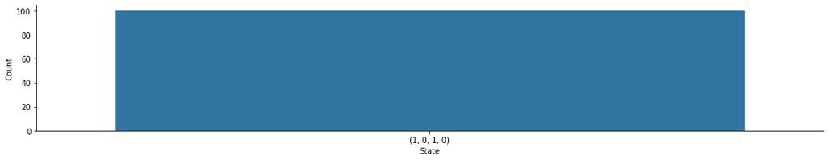

```python
from pytket.extensions.qiskit import AerBackend

circ1=circ.measure_all()
backend1 = AerBackend()  # connect to the backend
comp_c1=backend1.get_compiled_circuit(circ1,2) # compile the circuit to satisfy the backend's requirements
result_counts = backend1.run_circuit(comp_c1, n_shots=100).get_counts() # submit the job to run the circuit 100 times
plot_counts(result_counts)
```

```python
result_counts
```

```
Counter({(1, 0, 1, 0): 100})
```

Let's compile the circuit and run it on the IBM Guadalupe Emulator using TKET's optimization level 0.

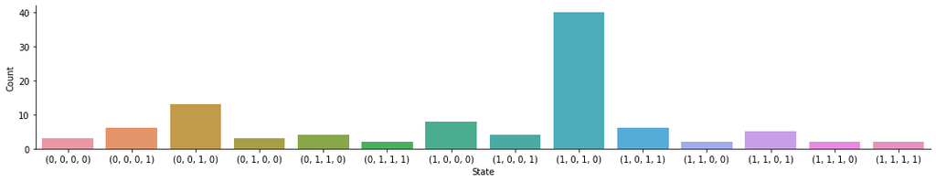

```python
backend2 = IBMQEmulatorBackend('ibmq_guadalupe', hub ='partner-cqc', group ='internal', project ='default')
circ2=circ.measure_all()
comp_c2=backend2.get_compiled_circuit(circ2,0)

handle2 = backend2.process_circuit(comp_c2, n_shots=100)
result2 = backend2.get_result(handle2)
counts2=result2.get_counts()
plot_counts(counts2)
```

```python
counts2
```

```
Counter({(0, 0, 0, 0): 3,
         (0, 0, 0, 1): 6,
         (0, 0, 1, 0): 13,
         (0, 1, 0, 0): 3,
         (0, 1, 1, 0): 4,
         (0, 1, 1, 1): 2,
         (1, 0, 0, 0): 8,
         (1, 0, 0, 1): 4,
         (1, 0, 1, 0): 40,
         (1, 0, 1, 1): 6,
         (1, 1, 0, 0): 2,
         (1, 1, 0, 1): 5,
         (1, 1, 1, 0): 2,
         (1, 1, 1, 1): 2})
```

Let's compile the circuit and run it on the IBM Guadalupe Emulator using TKET's optimization level 2.

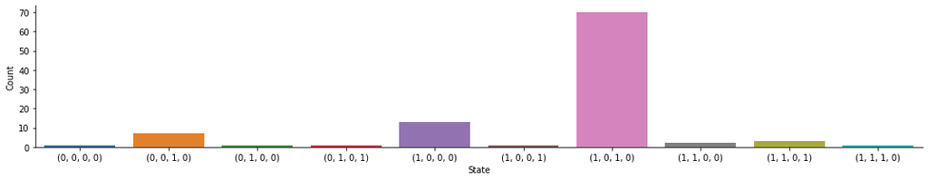

```python
comp_c3=backend2.get_compiled_circuit(circ2,2)

handle3 = backend2.process_circuit(comp_c3, n_shots=100)
result3 = backend2.get_result(handle3)
counts3=result3.get_counts()
plot_counts(counts3)
```

```python
counts3
```

```
Counter({(0, 0, 0, 0): 1,
         (0, 0, 1, 0): 7,
         (0, 1, 0, 0): 1,
         (0, 1, 0, 1): 1,
         (1, 0, 0, 0): 13,
         (1, 0, 0, 1): 1,
         (1, 0, 1, 0): 70,
         (1, 1, 0, 0): 2,
         (1, 1, 0, 1): 3,
         (1, 1, 1, 0): 1})
```

Now, let's compile the circuit and run it on the Quantinuum's H1-1 Emulator using TKET's optimization level 2.

```python
pip install pytket-quantinuum
```

```python
from pytket.extensions.quantinuum import QuantinuumBackend

backend3 = QuantinuumBackend('H1-1E') # emulator

comp_c4=backend3.get_compiled_circuit(circ2,2)

print(f"Our circuit has {comp_c4.n_gates} quantum gates in total and an overall")
print(f"depth of {comp_c4.depth()}.")
print(f"Of these gates {comp_c4.n_gates_of_type(OpType.ZZMax)} are two qubit gate, ZZMax, counts.")
```

```
Our circuit has 60 quantum gates in total and an overall
depth of 37.
Of these gates 17 are two qubit gate, ZZMax, counts.
```

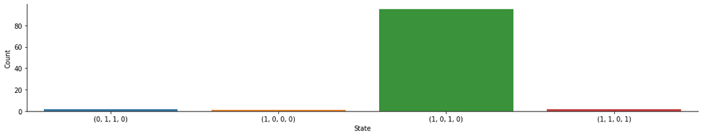

```python
handle4 = backend3.process_circuit(comp_c4, n_shots=100)
result4 = backend3.get_result(handle4)
counts4=result4.get_counts()
plot_counts(counts4)
```

```python
counts4
```

```
Counter({(0, 1, 1, 0): 2, (1, 0, 0, 0): 1, (1, 0, 1, 0): 95, (1, 1, 0, 1): 2})
```

### Compilation Summary for IBM Guadalupe

| Compiler | Compiler Version | Backend | Optimization Level | Counts for "1,0,1,0" state out of 100 |
| --- | --- | --- | --- | --- |
| TKET | 1.7.3 | Perfect Simulator | NA | 100 |
| TKET | 1.7.3 | Guadalupe Emulator | 0 | 40 |
| TKET | 1.7.3 | Guadalupe Emulator | 2 | 70 |
| TKET | 1.7.3 | H1-1 Emulator | 2 | 95 |

In today’s NISQ area, this difference in the reduction of the number of gates and hardware noise performance can matter, deciding between the success and failure of implementing a circuit on a real quantum computer.

## Workshop Summary

We have covered:

1. Installing and getting started with TKET and it's extensions.
2. Quantum gates, measurement and the construction of quantum circuits.
3. Tools that enable moving code between devices and software packages.
4. Steps required to prepare circuits to be run on a quantum computer.
5. Running circuits on quantum computers and classical simulators.

### Further Workshop Topics

- Predicates and Rebases
- Placement and mapping
- more on Optimization! (i.e. custom pass sequence)

### TKET specific Compiler Passes

- Synthesize many qubit operations to 1-, 2-qubit gates
- Symbolic expression optimization
- Resynthesize sub-circuits via special representations: ZX-terms, Clifford tableaux, Phase-polynomials / Phase gadget
- Exact and approximate synthesis of unitaries
- Architecture-aware synthesis
- Mapping to chosen gate basis
- Allocating “virtual” qubits to physical qubits
- Mapping and routing circuits to fixed architectures
- … more!

### Useful Links

- User manual → https://cqcl.github.io/pytket/manual/index.html
- TKET github → https://github.com/CQCL/tket
- Example notebooks → https://github.com/CQCL/pytket/tree/main/examples

Research Papers

- TKET paper → https://arxiv.org/abs/2003.10611
- Qubit Routing → https://arxiv.org/abs/1902.08091
- Phase Gadget Synthesis → https://arxiv.org/abs/1906.01734
- UCC Compilation → https://arxiv.org/abs/2007.10515

Public TKET Slack Channel to reach TKET dev team

- https://tketusers.slack.com/ssb/redirect#/shared-invite/email

# Questions

Kathrin Spendier → kathrin.spendier@quantinuum.com,

Notebook and slides available at: → https://github.com/spendierk/Q-SITE-Toronto-2022